# spatial3

Meredith Franklin

9/13/2019

## Setup

### Packages, Data, Maps

Load the following packages and load the PM data from lectures 1 and 2. Select November 10th, 2018 and merge the data with the sites. Project using CA Albers projection shown in lecture 2.

```r
library(ggplot2)
library(leaflet)
library(mapproj)
library(proj4)
library(geoR)
library(dplyr)
library(fields)

pm25 = read.csv("/Users/mf/Dropbox (University of Southern California)/Courses/PM569/Fall 2019/data/pm25_ca_2018.csv")
pm25.sites = read.csv("/Users/mf/Dropbox (University of Southern California)/Courses/PM569/Fall 2019/data/pm25_sites.csv")
pm_ca<-merge(pm25 %>% filter(date=="11/10/18"), pm25.sites, by='site_id')

proj_albers<-"+proj=aea +lat_1=34.0 +lat_2=40.5 +lon_0=-120.0 +x_0=0 +y_0=-4000000 +ellps=GRS80 +datum=NAD83 +units=km"

newcoords<-project(as.matrix(cbind(pm_ca$longitude, pm_ca$latitude)), proj=proj_albers)
pm_ca$x<-newcoords[,1]
pm_ca$y<-newcoords[,2]
```

Make a map of the PM2.5 concentrations

```r
pm.pal = colorNumeric(c('darkgreen','goldenrod','brown','brown'),
                        domain=pm_ca$pm25)
  leaflet(pm_ca) %>%
  addProviderTiles('CartoDB.Positron') %>%
  addCircles(lat=~latitude,lng=~longitude,label=~paste0(pm25, ' ug/m3'), color=~pm.pal(pm25),
             opacity=1, fillOpacity=1, radius=500) %>%
  addLegend('bottomleft', pal=pm.pal, values=pm_ca$pm25,
            title='PM2.5 (ug/m3)', opacity=1)
```

[interactive chart not shown]

## geoR objects and empirical semivariogram

Based on our results from last week we will use the log PM2.5 concentrations and use the Albers projected coordinates

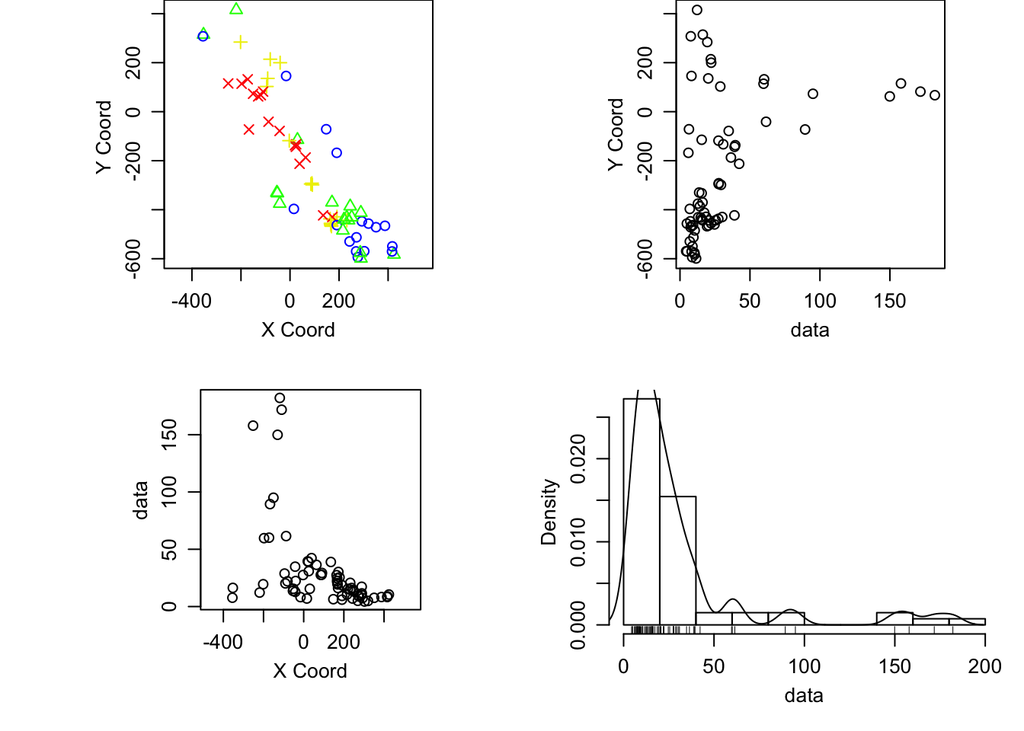

```r
# not logged
pm_geo_alb<-as.geodata(pm_ca,coords.col=c(7,8),data.col=3)
plot(pm_geo_alb)
```

```r
summary(pm_geo_alb)
```

```
## Number of data points: 68
##
## Coordinates summary
##             x         y
## min -354.9670 -599.0421
## max  424.1254  415.1952
##
## Distance summary
##         min         max
##    3.607555 1187.488641
##
## Data summary
##      Min.   1st Qu.    Median      Mean   3rd Qu.      Max.
##   4.40000  10.12500  17.95000  30.64118  29.52500 182.10000
```

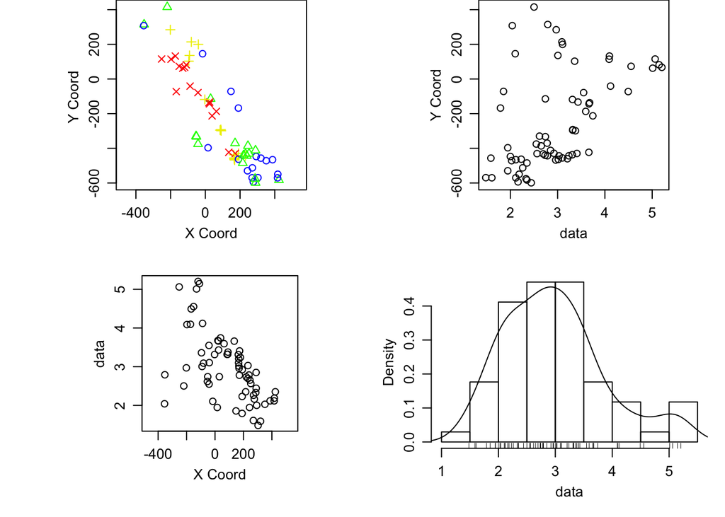

```r
# log pm25 better
pm_ca$logpm25<-log(pm_ca$pm25)
lpm_geo_alb<-as.geodata(pm_ca,coords.col=c(7,8),data.col=9)
plot(lpm_geo_alb)
```

```r
summary(lpm_geo_alb)
```

```
## Number of data points: 68
##
## Coordinates summary
##             x         y
## min -354.9670 -599.0421
## max  424.1254  415.1952
##
## Distance summary
##         min         max
##    3.607555 1187.488641
##
## Data summary
##     Min.  1st Qu.   Median     Mean  3rd Qu.     Max.
## 1.481605 2.314549 2.886934 2.972054 3.385151 5.204556
```

We fit theoretical functions by OLS, WLS, Maximum Likelihood: - OLS fits to bins, but does not consider the correlation between bins - WLS fits to bins and does consider the correlation between bins - MLE fits to ALL data, not the bins

Remember, for the binned empirical semivariograms it is best to use the Cressie-Hawkins robust estimator. We can compare fits using SSE (for the bin fits) and AIC for the MLE fits.

```r
# empirical semivariogram find distances
#cloud semivariogrm (ALL pairwise distances, a lot of points!)
vario1<-variog(lpm_geo_alb,option="cloud")
```

```
## variog: computing omnidirectional variogram
```

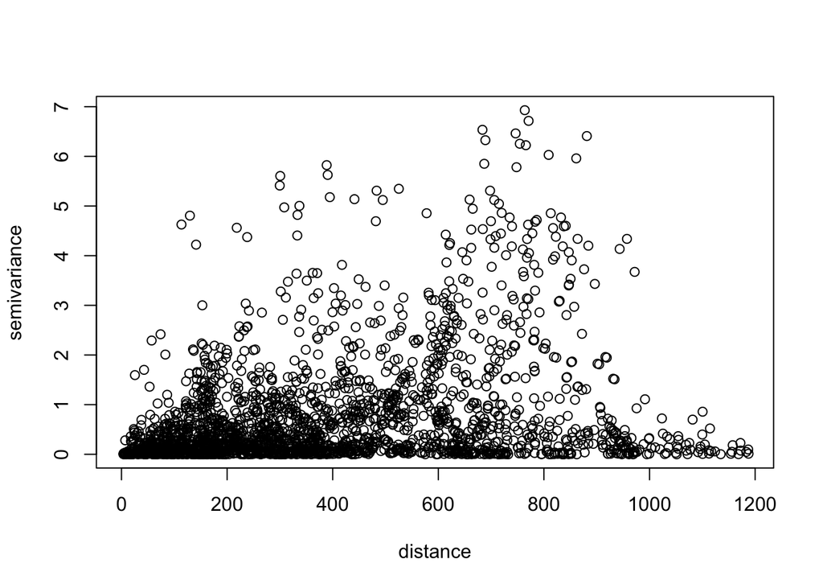

```r
plot(vario1)
```

```r
# binned semivariogram with C-H robust
# max dist 200 km, use 12 bins
vario2<-variog(lpm_geo_alb,uvec=seq(0,200,l=12),option="bin", estimator.type="modulus")
```

```
## variog: computing omnidirectional variogram
```

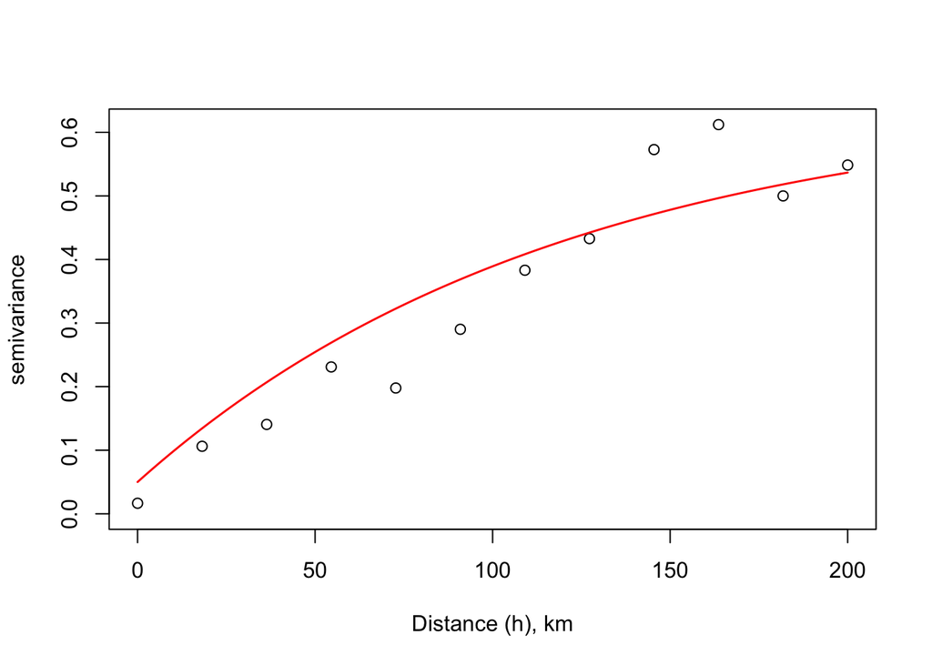

```r
plot(vario2,xlab="Distance (h), km")

# Eyeballed theoretical semivariogram (add curve to semivariogram plot)
curve(0.05+0.6*(1-exp(-x/120)),from = 0 , to=200, ylab="Semivariance", xlab="Distance (h)",add=T,col="red",lwd=1.5)
```

```r
# fitting semivariogram by ols
# ini.cov.pars (sigma2,phi)
vfit_ols=variofit(vario2,ini.cov.pars=c(0.5,100),nugget=0.05,fix.nugget=FALSE,cov.model='exponential', weights="equal")
```

```
## variofit: covariance model used is exponential
## variofit: weights used: equal
## variofit: minimisation function used: optim
```

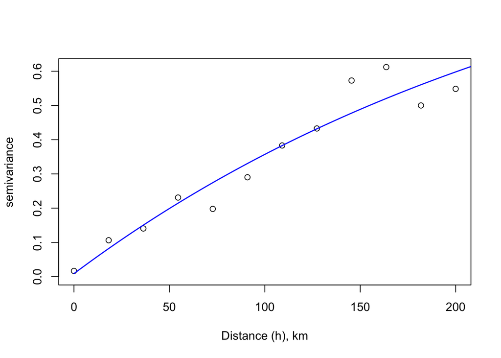

```r
plot(vario2,xlab="Distance (h), km")
# add ols fitted line to the binned semivariogram and eyeballed curve
lines(vfit_ols,col="blue",lwd=1.5)
```

```r
# summarizing the fit to get parameter estimates
summary(vfit_ols)
```

```
## $pmethod
## [1] "OLS (ordinary least squares)"
##
## $cov.model
## [1] "exponential"
##
## $spatial.component
##   sigmasq       phi
##   1.12993 271.29162
##
## $spatial.component.extra
## kappa
##   0.5
##
## $nugget.component
##       tausq
## 0.008683649
##
## $fix.nugget
## [1] FALSE
##
## $fix.kappa
## [1] TRUE
##
## $practicalRange
## [1] 812.7171
##
## $sum.of.squares
##      value
## 0.03209193
##
## $estimated.pars
##        tausq      sigmasq          phi
## 8.683649e-03 1.129930e+00 2.712916e+02
##
## $weights
## [1] "equal"
##
## $call
## variofit(vario = vario2, ini.cov.pars = c(0.5, 100), cov.model = "exponential",
##     fix.nugget = FALSE, nugget = 0.05, weights = "equal")
##
## attr(,"class")
## [1] "summary.variomodel"
```

```r
# fitting semivariogram by wls
vfit_wls=variofit(vario2,ini.cov.pars=c(0.5,100),nugget=0.05,fix.nugget=FALSE,cov.model='exponential',weights='cressie')
```

```
## variofit: covariance model used is exponential
## variofit: weights used: cressie
## variofit: minimisation function used: optim
```

```r
plot(vario2,xlab="Distance (h), km")
lines(vfit_wls,col="purple",lwd=1.5)

summary(vfit_wls)
```

```
## $pmethod
## [1] "WLS (weighted least squares)"
##
## $cov.model
## [1] "exponential"
##
## $spatial.component
##    sigmasq        phi
##  0.5960552 99.9999642
##
## $spatial.component.extra
## kappa
##   0.5
##
## $nugget.component
##      tausq
## 0.01516241
##
## $fix.nugget
## [1] FALSE
##
## $fix.kappa
## [1] TRUE
##
## $practicalRange
## [1] 299.5731
##
## $sum.of.squares
##    value
## 26.88978
##
## $estimated.pars
##       tausq     sigmasq         phi
##  0.01516241  0.59605518 99.99996419
##
## $weights
## [1] "cressie"
##
## $call
## variofit(vario = vario2, ini.cov.pars = c(0.5, 100), cov.model = "exponential",
##     fix.nugget = FALSE, nugget = 0.05, weights = "cressie")
##
## attr(,"class")
## [1] "summary.variomodel"
```

```r
# change model type to gaussian
vfit_wls2=variofit(vario2,ini.cov.pars=c(0.5,100),nugget=0.05,fix.nugget=FALSE,cov.model='gaussian',weights='cressie')
```

```
## variofit: covariance model used is gaussian
## variofit: weights used: cressie
## variofit: minimisation function used: optim
```

```r
#plot(vario2,xlab="Distance (h), km")
lines(vfit_wls2,col="cyan",lwd=1.5)

summary(vfit_wls2)
```

```
## $pmethod
## [1] "WLS (weighted least squares)"
##
## $cov.model
## [1] "gaussian"
##
## $spatial.component
##     sigmasq         phi
##   0.5401366 120.4718724
##
## $spatial.component.extra
## kappa
##   0.5
##
## $nugget.component
##      tausq
## 0.09372247
##
## $fix.nugget
## [1] FALSE
##
## $fix.kappa
## [1] TRUE
##
## $practicalRange
## [1] 208.5149
##
## $sum.of.squares
##    value
## 19.79671
##
## $estimated.pars
##        tausq      sigmasq          phi
##   0.09372247   0.54013663 120.47187239
##
## $weights
## [1] "cressie"
##
## $call
## variofit(vario = vario2, ini.cov.pars = c(0.5, 100), cov.model = "gaussian",
##     fix.nugget = FALSE, nugget = 0.05, weights = "cressie")
##
## attr(,"class")
## [1] "summary.variomodel"
```

```r
# change around values of initial parameters, max.dist, nugget to see what happens
vfit_wls3=variofit(vario2,ini.cov.pars=c(0.3,50),nugget=0.01,max.dist=100,cov.model='gaussian',weights='cressie')
```

```
## variofit: covariance model used is gaussian
## variofit: weights used: cressie
## variofit: minimisation function used: optim
```

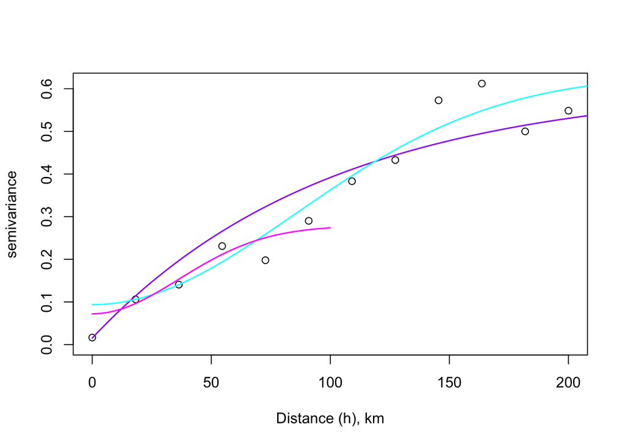

```r
#plot(vario2,xlab="Distance (h), km")
lines(vfit_wls3,col="magenta",lwd=1.5)
```

```r
summary(vfit_wls3)
```

```
## $pmethod
## [1] "WLS (weighted least squares)"
##
## $cov.model
## [1] "gaussian"
##
## $spatial.component
##    sigmasq        phi
##  0.2063154 51.4374857
##
## $spatial.component.extra
## kappa
##   0.5
##
## $nugget.component
##      tausq
## 0.07218704
##
## $fix.nugget
## [1] FALSE
##
## $fix.kappa
## [1] TRUE
##
## $practicalRange
## [1] 89.02896
##
## $sum.of.squares
##    value
## 11.97032
##
## $estimated.pars
##       tausq     sigmasq         phi
##  0.07218704  0.20631537 51.43748565
##
## $weights
## [1] "cressie"
##
## $call
## variofit(vario = vario2, ini.cov.pars = c(0.3, 50), cov.model = "gaussian",
##     nugget = 0.01, max.dist = 100, weights = "cressie")
##
## attr(,"class")
## [1] "summary.variomodel"
```

```r
# fitting covariance functions by maximum likelihood
# choose method='ML' or 'REML', cov.model (exponential, gaussian, matern, spherical, etc.),
# trend, be careful of range parameter

mlfit_exp=likfit(lpm_geo_alb,ini.cov.pars=c(0.5,100),nugget=0.05, fix.nugget=FALSE, cov.model='exponential', lik.method='ML')
```

[output not shown]

```r
summary(mlfit_exp)
```

```
## Summary of the parameter estimation
## -----------------------------------
## Estimation method: maximum likelihood
##
## Parameters of the mean component (trend):
##   beta
## 2.7633
##
## Parameters of the spatial component:
##    correlation function: exponential
##       (estimated) variance parameter sigmasq (partial sill) =  0.8776
##       (estimated) cor. fct. parameter phi (range parameter)  =  167.7
##    anisotropy parameters:
##       (fixed) anisotropy angle = 0  ( 0 degrees )
##       (fixed) anisotropy ratio = 1
##
## Parameter of the error component:
##       (estimated) nugget =  0
##
## Transformation parameter:
##       (fixed) Box-Cox parameter = 1 (no transformation)
##
## Practical Range with cor=0.05 for asymptotic range: 502.3755
##
## Maximised Likelihood:
##    log.L n.params      AIC      BIC
## "-45.21"      "4"  "98.42"  "107.3"
##
## non spatial model:
##    log.L n.params      AIC      BIC
## "-87.11"      "2"  "178.2"  "182.7"
##
## Call:
## likfit(geodata = lpm_geo_alb, ini.cov.pars = c(0.5, 100), fix.nugget = FALSE,
##     nugget = 0.05, cov.model = "exponential", lik.method = "ML")
```

```r
mlfit_gau=likfit(lpm_geo_alb,ini.cov.pars=c(0.5,100),nugget=0.05, fix.nugget=FALSE,cov.model='gaussian', lik.method='ML')
```

[output not shown]

```r
summary(mlfit_gau)
```

```
## Summary of the parameter estimation
## -----------------------------------
## Estimation method: maximum likelihood
##
## Parameters of the mean component (trend):
##   beta
## 2.9326
##
## Parameters of the spatial component:
##    correlation function: gaussian
##       (estimated) variance parameter sigmasq (partial sill) =  0.6781
##       (estimated) cor. fct. parameter phi (range parameter)  =  129.5
##    anisotropy parameters:
##       (fixed) anisotropy angle = 0  ( 0 degrees )
##       (fixed) anisotropy ratio = 1
##
## Parameter of the error component:
##       (estimated) nugget =  0.1024
##
## Transformation parameter:
##       (fixed) Box-Cox parameter = 1 (no transformation)
##
## Practical Range with cor=0.05 for asymptotic range: 224.2018
##
## Maximised Likelihood:
##    log.L n.params      AIC      BIC
## "-49.86"      "4"  "107.7"  "116.6"
##
## non spatial model:
##    log.L n.params      AIC      BIC
## "-87.11"      "2"  "178.2"  "182.7"
##
## Call:
## likfit(geodata = lpm_geo_alb, ini.cov.pars = c(0.5, 100), fix.nugget = FALSE,
##     nugget = 0.05, cov.model = "gaussian", lik.method = "ML")
```

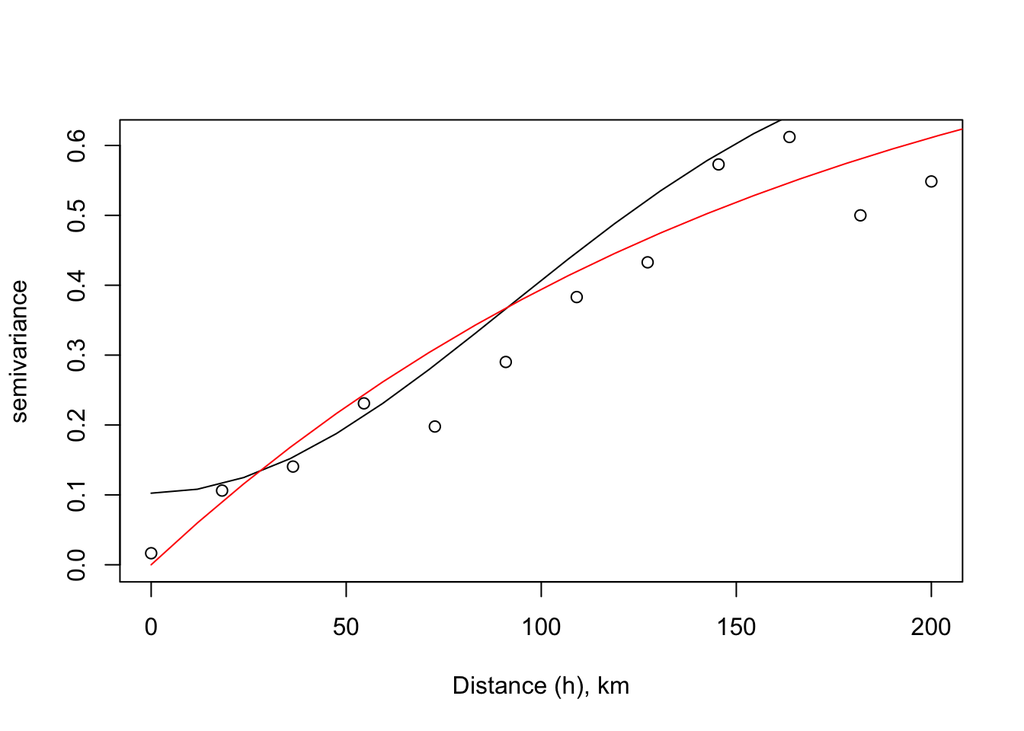

```r
#plot
plot(vario2,xlab="Distance (h), km")
lines(mlfit_gau)
lines(mlfit_exp,col="red")
```

```r
# restricted maximum likelihood
remlfit_gau=likfit(lpm_geo_alb,ini.cov.pars=c(0.5,100),nugget=0.05, fix.nugget=FALSE,cov.model='gaussian', lik.method='REML')
```

[output not shown]

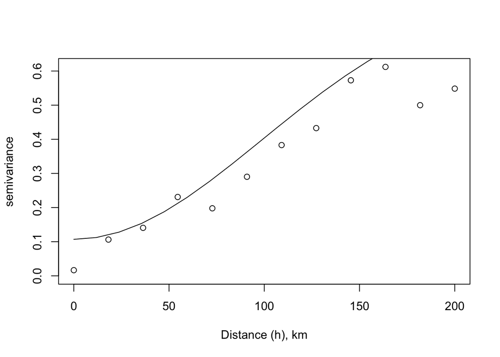

```r
plot(vario2,xlab="Distance (h), km")
lines(remlfit_gau)
```

```r
summary(remlfit_gau)
```

```
## Summary of the parameter estimation
## -----------------------------------
## Estimation method: restricted maximum likelihood
##
## Parameters of the mean component (trend):
##   beta
## 2.9198
##
## Parameters of the spatial component:
##    correlation function: gaussian
##       (estimated) variance parameter sigmasq (partial sill) =  0.7388
##       (estimated) cor. fct. parameter phi (range parameter)  =  139.5
##    anisotropy parameters:
##       (fixed) anisotropy angle = 0  ( 0 degrees )
##       (fixed) anisotropy ratio = 1
##
## Parameter of the error component:
##       (estimated) nugget =  0.1069
##
## Transformation parameter:
##       (fixed) Box-Cox parameter = 1 (no transformation)
##
## Practical Range with cor=0.05 for asymptotic range: 241.3673
##
## Maximised Likelihood:
##    log.L n.params      AIC      BIC
## "-48.12"      "4"  "104.2"  "113.1"
##
## non spatial model:
##    log.L n.params      AIC      BIC
## "-86.32"      "2"  "176.6"  "181.1"
##
## Call:
## likfit(geodata = lpm_geo_alb, ini.cov.pars = c(0.5, 100), fix.nugget = FALSE,
##     nugget = 0.05, cov.model = "gaussian", lik.method = "REML")
```

```r
# including a linear trend -- does this help?
# first check linear trend in lm (linear regression). Look at regression parameter estimates, are they stat sig?
ltrend<-lm(logpm25~y+x,dat=pm_ca)
summary(ltrend)
```

```
##
## Call:
## lm(formula = logpm25 ~ y + x, data = pm_ca)
##
## Residuals:
##     Min      1Q  Median      3Q     Max
## -2.1269 -0.3841  0.0983  0.4314  1.7051
##
## Coefficients:
##               Estimate Std. Error t value Pr(>|t|)
## (Intercept)  3.1276876  0.1341716  23.311  < 2e-16 ***
## y           -0.0006420  0.0007108  -0.903  0.36973
## x           -0.0034878  0.0010304  -3.385  0.00121 **
## ---
## Signif. codes:  0 '***' 0.001 '**' 0.01 '*' 0.05 '.' 0.1 ' ' 1
##
## Residual standard error: 0.7216 on 65 degrees of freedom
## Multiple R-squared:  0.3441, Adjusted R-squared:  0.324
## F-statistic: 17.05 on 2 and 65 DF,  p-value: 1.113e-06
```

```r
# add linear trend to likelihood fit
remlfit_gau_trend=likfit(lpm_geo_alb,ini.cov.pars=c(0.5,100),nugget=0.05, fix.nugget=FALSE,cov.model='gaussian', lik.method='REML',trend='1st')
```

[output not shown]

```r
summary(remlfit_gau_trend)
```

```
## Summary of the parameter estimation
## -----------------------------------
## Estimation method: restricted maximum likelihood
##
## Parameters of the mean component (trend):
##   beta0   beta1   beta2
##  2.8404 -0.0040 -0.0016
##
## Parameters of the spatial component:
##    correlation function: gaussian
##       (estimated) variance parameter sigmasq (partial sill) =  0.5443
##       (estimated) cor. fct. parameter phi (range parameter)  =  87.24
##    anisotropy parameters:
##       (fixed) anisotropy angle = 0  ( 0 degrees )
##       (fixed) anisotropy ratio = 1
##
## Parameter of the error component:
##       (estimated) nugget =  0.0737
##
## Transformation parameter:
##       (fixed) Box-Cox parameter = 1 (no transformation)
##
## Practical Range with cor=0.05 for asymptotic range: 150.99
##
## Maximised Likelihood:
##    log.L n.params      AIC      BIC
## "-42.86"      "6"  "97.72"    "111"
##
## non spatial model:
##    log.L n.params      AIC      BIC
## "-71.02"      "4"    "150"  "158.9"
##
## Call:
## likfit(geodata = lpm_geo_alb, trend = "1st", ini.cov.pars = c(0.5,
##     100), fix.nugget = FALSE, nugget = 0.05, cov.model = "gaussian",
##     lik.method = "REML")
```

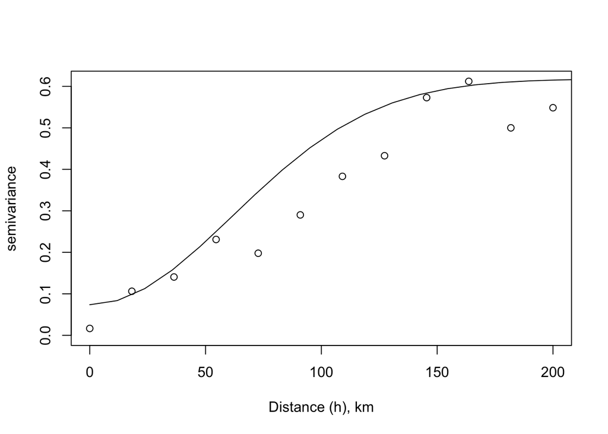

```r
plot(vario2,xlab="Distance (h), km")
lines(remlfit_gau_trend)
```

## Kriging

For kriging, we are taking a fitted semivariogram, converting the function to a covariance (R dose it for us) and then interpolating the point referenced data to unobserved locations. - Can interpolate to other point locations - Can interpolate to a fine grid to get an interpolated surface

We need the fields() package to easily do image plots to check our results.

```r
# kriging with likelihood fit
# create grid for kriging/interpolation

res=60
xs=seq(min(pm_ca$x),max(pm_ca$x),len=res)
ys=seq(min(pm_ca$y),max(pm_ca$y),len=res)
myGrid=expand.grid(xs,ys)
names(myGrid)=c('y','x')
# names of grid coordinates must match coordinate names in dataset that is being kriged

# kiriging with no trend (cte mean)
kriged_grid=krige.conv(lpm_geo_alb,locations=myGrid,krige=krige.control(obj.model=remlfit_gau), output=output.control(signal=TRUE))
```

```
## krige.conv: model with constant mean
## krige.conv: Kriging performed using global neighbourhood
```

```r
# kiriging with linear trend
kriged_grid_trend=krige.conv(lpm_geo_alb,locations=myGrid,krige=krige.control(obj.model=remlfit_gau_trend,trend.d='1st',trend.l='1st'), output=output.control(signal=TRUE))
```

```
## krige.conv: model with mean given by a 1st order polynomial on the coordinates
## krige.conv: Kriging performed using global neighbourhood
```

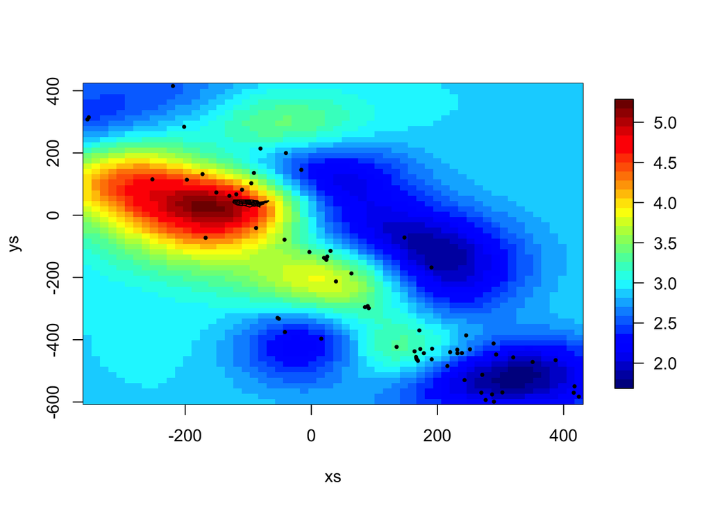

```r
#plot on grid
image.plot(xs,ys,matrix(kriged_grid$predict,res,res,byrow=FALSE),col=tim.colors(32))
map('state',add=TRUE)# project MAP!!!
points(pm_ca$x, pm_ca$y, pch=19,cex=0.4)
```

## Kriging results on a nicer map

- We need to transform the coordinates back to lat and lon
- Also, since we logged the data we should exponentiate the predictions

```r
proj_albers<-"+proj=aea +lat_1=34.0 +lat_2=40.5 +lon_0=-120.0 +x_0=0 +y_0=-4000000 +ellps=GRS80 +datum=NAD83 +units=km"
myGrid_ll<- project(myGrid, proj_albers, inverse=TRUE)


preds = data.frame(myGrid_ll, pred.pm=exp(kriged_grid$predict) %>% as.vector)
pred.pal = colorNumeric(c('darkgreen','gold1','brown'),
                             domain=preds$pred.pm)
preds %>%
  leaflet() %>%
  addProviderTiles("CartoDB.Positron") %>%
  addCircles(lng=~x, lat=~y, color=~pred.pal(pred.pm),
             opacity=.7, fillOpacity=.7, radius=1e3) %>% # points w/ 1KM radius
  addLegend('bottomleft', pal=pred.pal, values=preds$pred.pm,
            title="Pred. PM2.5", opacity=.5)
```

[interactive chart not shown]